# Practical Machine Learning Project

## Author: Kevin

## Project task:

To build a machine learning algorithm to predict personal activity quality (how well) from activity monitors

## Get training and testing data sets

```r
#create working dir if not exist
if (!file.exists("data")) dir.create("data")
setwd("data") ## ==  setwd("./data")

#download raw data
setInternet2(use=T)
fileUrl_trainingData<-"https://d396qusza40orc.cloudfront.net/predmachlearn/pml-training.csv"
fileUrl_testData<-"https://d396qusza40orc.cloudfront.net/predmachlearn/pml-testing.csv"
download.file(fileUrl_trainingData, destfile="./trainingData.csv")
download.file(fileUrl_testData, destfile="./testData.csv")

list.files("./")
```

[1] “testData.csv” “trainingData.csv”

```r
dateDownloaded<-date()

trainingSet<-read.csv("trainingData.csv")
testingSet<-read.csv("testData.csv")
```

## Data cleaning

For the same variables in interest, they are even of different types (factor vs. logical) in training/testing data, all are converted to numeric type before processing (except responsor: “classe”" variable)

```r
dim(trainingSet)
```

[1] 19622 160

```r
dim(testingSet)
```

[1] 20 160

```r
#show the first 15 variables in each set, where several varibles have two different types
classTrain<-sapply(trainingSet[,1:15],class)
classTest<-sapply(testingSet[,1:15],class)
classTable<-cbind(classTrain,classTest)
rownames(classTable)<-names(trainingSet[,1:15])
knitr::kable(classTable)
```

|  | classTrain | classTest |
| --- | --- | --- |
| X | integer | integer |
| user_name | factor | factor |
| raw_timestamp_part_1 | integer | integer |
| raw_timestamp_part_2 | integer | integer |
| cvtd_timestamp | factor | factor |
| new_window | factor | factor |
| num_window | integer | integer |
| roll_belt | numeric | numeric |
| pitch_belt | numeric | numeric |
| yaw_belt | numeric | numeric |
| total_accel_belt | integer | integer |
| kurtosis_roll_belt | factor | logical |
| kurtosis_picth_belt | factor | logical |
| kurtosis_yaw_belt | factor | logical |
| skewness_roll_belt | factor | logical |

```r
#convert all variables to numeric type except classe (keep as factor) in both training and testing sets
classeInd<-grep("classe",names(trainingSet))
classeInd
```

[1] 160

```r
problemInd<-grep("problem_id",names(testingSet))
problemInd
```

[1] 160

```r
trainingSet[,-classeInd]<-data.frame(sapply(trainingSet[,-classeInd],as.numeric))
testingSet[,-problemInd]<-data.frame(sapply(testingSet[,-problemInd],as.numeric))
dim(trainingSet)
```

[1] 19622 160

```r
dim(testingSet)
```

[1] 20 160

## Data exploration

1. Let’s first see how many variables related to all sensors, Eular angles and features

```r
extract<-grep("accel|gyros|magnet|belt|arm|forearm|dumbbell|roll|pitch|yaw",names(trainingSet),value=T)
length(extract)
```

[1] 152

```r
extract
```

[1] “roll_belt” “pitch_belt”  
[3] “yaw_belt” “total_accel_belt”  
[5] “kurtosis_roll_belt” “kurtosis_picth_belt”  
[7] “kurtosis_yaw_belt” “skewness_roll_belt”  
[9] “skewness_roll_belt.1” “skewness_yaw_belt”  
[11] “max_roll_belt” “max_picth_belt”  
[13] “max_yaw_belt” “min_roll_belt”  
[15] “min_pitch_belt” “min_yaw_belt”  
[17] “amplitude_roll_belt” “amplitude_pitch_belt”  
[19] “amplitude_yaw_belt” “var_total_accel_belt”  
[21] “avg_roll_belt” “stddev_roll_belt”  
[23] “var_roll_belt” “avg_pitch_belt”  
[25] “stddev_pitch_belt” “var_pitch_belt”  
[27] “avg_yaw_belt” “stddev_yaw_belt”  
[29] “var_yaw_belt” “gyros_belt_x”  
[31] “gyros_belt_y” “gyros_belt_z”  
[33] “accel_belt_x” “accel_belt_y”  
[35] “accel_belt_z” “magnet_belt_x”  
[37] “magnet_belt_y” “magnet_belt_z”  
[39] “roll_arm” “pitch_arm”  
[41] “yaw_arm” “total_accel_arm”  
[43] “var_accel_arm” “avg_roll_arm”  
[45] “stddev_roll_arm” “var_roll_arm”  
[47] “avg_pitch_arm” “stddev_pitch_arm”  
[49] “var_pitch_arm” “avg_yaw_arm”  
[51] “stddev_yaw_arm” “var_yaw_arm”  
[53] “gyros_arm_x” “gyros_arm_y”  
[55] “gyros_arm_z” “accel_arm_x”  
[57] “accel_arm_y” “accel_arm_z”  
[59] “magnet_arm_x” “magnet_arm_y”  
[61] “magnet_arm_z” “kurtosis_roll_arm”  
[63] “kurtosis_picth_arm” “kurtosis_yaw_arm”  
[65] “skewness_roll_arm” “skewness_pitch_arm”  
[67] “skewness_yaw_arm” “max_roll_arm”  
[69] “max_picth_arm” “max_yaw_arm”  
[71] “min_roll_arm” “min_pitch_arm”  
[73] “min_yaw_arm” “amplitude_roll_arm”  
[75] “amplitude_pitch_arm” “amplitude_yaw_arm”  
[77] “roll_dumbbell” “pitch_dumbbell”  
[79] “yaw_dumbbell” “kurtosis_roll_dumbbell”  
[81] “kurtosis_picth_dumbbell” “kurtosis_yaw_dumbbell”  
[83] “skewness_roll_dumbbell” “skewness_pitch_dumbbell” [85] “skewness_yaw_dumbbell” “max_roll_dumbbell”  
[87] “max_picth_dumbbell” “max_yaw_dumbbell”  
[89] “min_roll_dumbbell” “min_pitch_dumbbell”  
[91] “min_yaw_dumbbell” “amplitude_roll_dumbbell” [93] “amplitude_pitch_dumbbell” “amplitude_yaw_dumbbell”  
[95] “total_accel_dumbbell” “var_accel_dumbbell”  
[97] “avg_roll_dumbbell” “stddev_roll_dumbbell”  
[99] “var_roll_dumbbell” “avg_pitch_dumbbell”  
[101] “stddev_pitch_dumbbell” “var_pitch_dumbbell”  
[103] “avg_yaw_dumbbell” “stddev_yaw_dumbbell”  
[105] “var_yaw_dumbbell” “gyros_dumbbell_x”  
[107] “gyros_dumbbell_y” “gyros_dumbbell_z”  
[109] “accel_dumbbell_x” “accel_dumbbell_y”  
[111] “accel_dumbbell_z” “magnet_dumbbell_x”  
[113] “magnet_dumbbell_y” “magnet_dumbbell_z”  
[115] “roll_forearm” “pitch_forearm”  
[117] “yaw_forearm” “kurtosis_roll_forearm”  
[119] “kurtosis_picth_forearm” “kurtosis_yaw_forearm”  
[121] “skewness_roll_forearm” “skewness_pitch_forearm”  
[123] “skewness_yaw_forearm” “max_roll_forearm”  
[125] “max_picth_forearm” “max_yaw_forearm”  
[127] “min_roll_forearm” “min_pitch_forearm”  
[129] “min_yaw_forearm” “amplitude_roll_forearm”  
[131] “amplitude_pitch_forearm” “amplitude_yaw_forearm”  
[133] “total_accel_forearm” “var_accel_forearm”  
[135] “avg_roll_forearm” “stddev_roll_forearm”  
[137] “var_roll_forearm” “avg_pitch_forearm”  
[139] “stddev_pitch_forearm” “var_pitch_forearm”  
[141] “avg_yaw_forearm” “stddev_yaw_forearm”  
[143] “var_yaw_forearm” “gyros_forearm_x”  
[145] “gyros_forearm_y” “gyros_forearm_z”  
[147] “accel_forearm_x” “accel_forearm_y”  
[149] “accel_forearm_z” “magnet_forearm_x”  
[151] “magnet_forearm_y” “magnet_forearm_z”

2. It can be seen that 152 variables could be candidates as predictors. Let’s randomly select one variable, say “roll_belt” to see what’s its relationshp with classe using plotting.

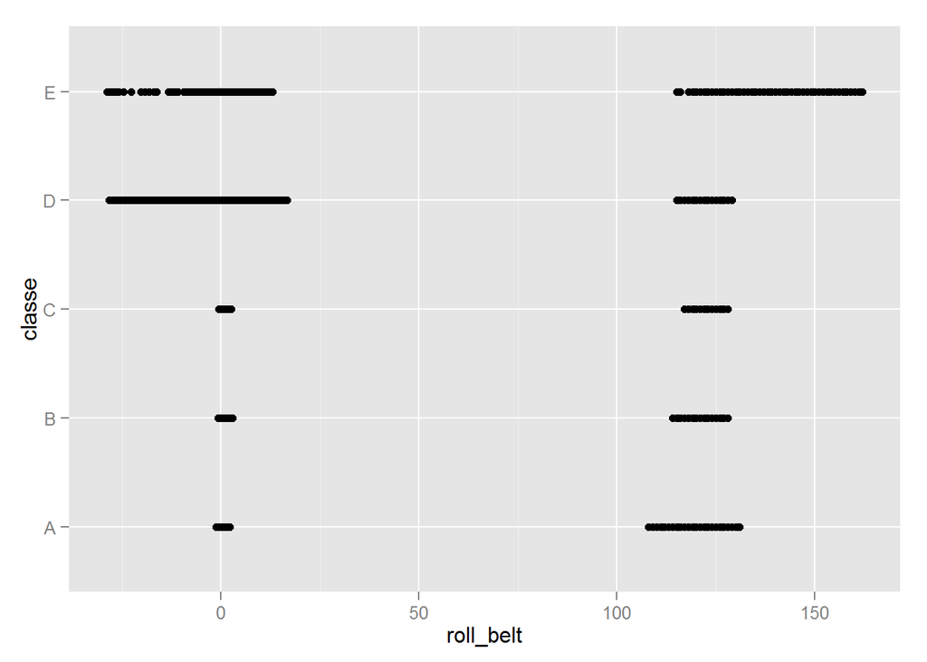

```r
qplot(roll_belt,classe,data=trainingSet)
```

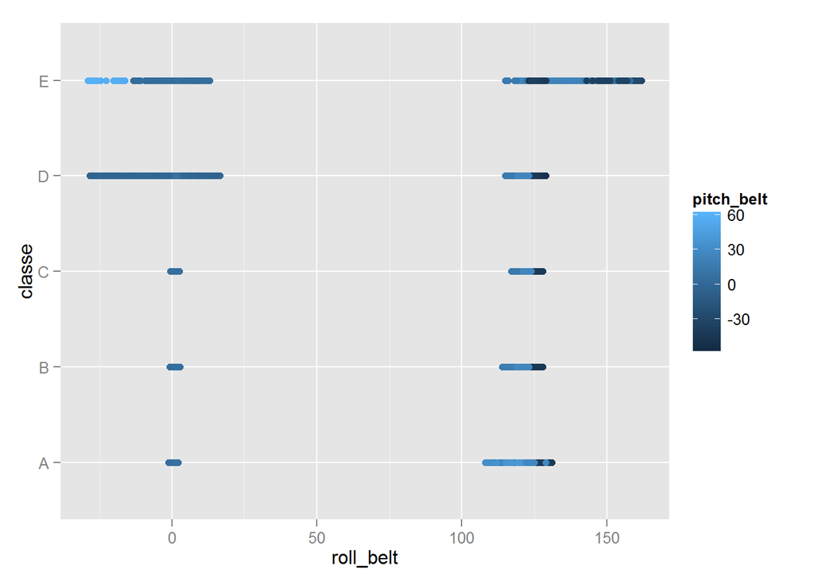

```r
qplot(roll_belt,classe,colour=pitch_belt, data=trainingSet)
```

From the plotting it looks for belt, roll and pitch variables can be used as predictors.

3. Let’s also take a look at if any correlation between those accelerometer-on-belt related variables and classe

```r
accelBeltInd<-grep("accel.+belt",names(trainingSet))
length(accelBeltInd)
```

[1] 5

```r
names(trainingSet)[accelBeltInd]
```

[1] “total_accel_belt” “var_total_accel_belt” “accel_belt_x”  
[4] “accel_belt_y” “accel_belt_z”

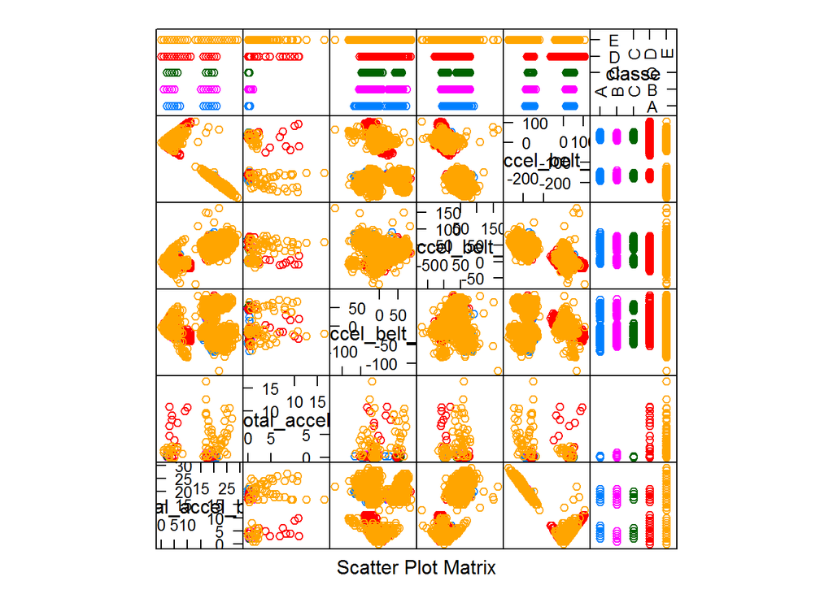

```r
featurePlot(x=trainingSet[,c(accelBeltInd,classeInd)],y=trainingSet$classe,plot="pairs")
```

It can be seen the accelerometer-on-belt variables could also be considered as predictors

## Feature selection:

-1. As indicated in project b/g, “your goal will be to use data from accelerometers on the belt, forearm, arm, and dumbell of 6 participants.” In the project instruction it also says that “You may use any of the other variables to predict with.”  
–1.1 Initially I used all data related to only accelerometers on the belt, forearm, arm and dumbbell, which gives me >94% prediction accuracy.  
–1.2 I do find if I used more variables in my model, that is, all data related to Eular Angles (roll,pitch,yaw) and all three sensors (accelerometers,gyros- and magnetometers) on the belt, forearm, arm and dumbbell, the model can achieve even higher prediction accuracy (>99%) see below. Thus in this project I will see which out of those 152 variables I can use as predictors for building up my model.

```r
#extract all data from eular angels (roll, pitch, yaw) and sensors (accelerameters, gyros and magnetometers) on the belt, forearm, arm and dumbbell

extract<-grep("roll|pitch|yaw|accel|gyros|magnet|belt|arm|forearm|dumbbell",names(trainingSet))
#extract all data from accelerameters on the belt, forearm, arm and dumbbell
#extract<-grep("(accel.+belt)|(accel.+arm)|(accel.+forearm)|(accel.+dumbbell)",names(trainingSet))
length(extract)
```

[1] 152

```r
training<-trainingSet[,c(extract,classeInd)]
dim(training)
```

[1] 19622 153

```r
testing<-testingSet[,c(extract,problemInd)]
dim(testing)
```

[1] 20 153

Here We found 152 predictors

2. All NZV(Near Zero Variance) variables should be removed from the data as predictors.

```r
#find and show all those NZV variables in training/testing sets
nsvTraining<-nearZeroVar(training[,-dim(training)[2]],saveMetrics=TRUE)
nsvTesting<-nearZeroVar(testing[,-dim(testing)[2]],saveMetrics=TRUE)
nzvTable<-data.frame(nsvTraining$percentUnique,as.logical(nsvTraining$nzv),nsvTesting$percentUnique,as.logical(nsvTesting$nzv))
rownames(nzvTable)<-names(training[,-dim(training)[2]])
colnames(nzvTable)<-c("%Unique_Training","NZV_Training", "%Unique_Testing","NZV_Testing")
knitr::kable(nzvTable)
```

|  | %Unique_Training | NZV_Training | %Unique_Testing | NZV_Testing |
| --- | --- | --- | --- | --- |
| roll_belt | 6.7781062 | FALSE | 90 | FALSE |
| pitch_belt | 9.3772296 | FALSE | 100 | FALSE |
| yaw_belt | 9.9734991 | FALSE | 90 | FALSE |
| total_accel_belt | 0.1477933 | FALSE | 45 | FALSE |
| kurtosis_roll_belt | 2.0232392 | TRUE | 0 | TRUE |
| kurtosis_picth_belt | 1.6155336 | TRUE | 0 | TRUE |
| kurtosis_yaw_belt | 0.0101926 | TRUE | 0 | TRUE |
| skewness_roll_belt | 2.0130466 | TRUE | 0 | TRUE |
| skewness_roll_belt.1 | 1.7225563 | TRUE | 0 | TRUE |
| skewness_yaw_belt | 0.0101926 | TRUE | 0 | TRUE |
| max_roll_belt | 0.9937825 | FALSE | 0 | TRUE |
| max_picth_belt | 0.1121191 | FALSE | 0 | TRUE |
| max_yaw_belt | 0.3465498 | TRUE | 0 | TRUE |
| min_roll_belt | 0.9377230 | FALSE | 0 | TRUE |
| min_pitch_belt | 0.0815411 | FALSE | 0 | TRUE |
| min_yaw_belt | 0.3465498 | TRUE | 0 | TRUE |
| amplitude_roll_belt | 0.7542554 | FALSE | 0 | TRUE |
| amplitude_pitch_belt | 0.0662522 | FALSE | 0 | TRUE |
| amplitude_yaw_belt | 0.0203853 | TRUE | 0 | TRUE |
| var_total_accel_belt | 0.3312608 | FALSE | 0 | TRUE |
| avg_roll_belt | 0.9733972 | FALSE | 0 | TRUE |
| stddev_roll_belt | 0.3516461 | FALSE | 0 | TRUE |
| var_roll_belt | 0.4892468 | FALSE | 0 | TRUE |
| avg_pitch_belt | 1.0906126 | FALSE | 0 | TRUE |
| stddev_pitch_belt | 0.2191418 | FALSE | 0 | TRUE |
| var_pitch_belt | 0.3210682 | FALSE | 0 | TRUE |
| avg_yaw_belt | 1.2231169 | FALSE | 0 | TRUE |
| stddev_yaw_belt | 0.2955866 | FALSE | 0 | TRUE |
| var_yaw_belt | 0.7389665 | FALSE | 0 | TRUE |
| gyros_belt_x | 0.7134849 | FALSE | 70 | FALSE |

[output cut: 122 more lines]

```r
#find index of those NZV variables in data and remove them
nzvIndTraining<-which(nsvTraining$nzv)
nzvIndTesting<-which(nsvTesting$nzv)
nzvInd<-c(nzvIndTraining,nzvIndTesting)
#Number and index of those NZV variables in training set
length(nzvIndTraining)
```

[1] 59

```r
nzvIndTraining
```

[1] 5 6 7 8 9 10 13 16 19 44 45 46 47 48 49 50 51 [18] 52 62 63 64 65 66 67 68 71 72 74 75 80 81 82 83 84 [35] 85 88 91 94 118 119 120 121 122 123 124 126 127 129 130 132 135 [52] 136 137 138 139 140 141 142 143

```r
#Number and index of those NZV variables in testing set
length(nzvIndTesting)
```

[1] 100

```r
nzvIndTesting
```

[1] 5 6 7 8 9 10 11 12 13 14 15 16 17 18 19 20 21 [18] 22 23 24 25 26 27 28 29 43 44 45 46 47 48 49 50 51 [35] 52 62 63 64 65 66 67 68 69 70 71 72 73 74 75 76 80 [52] 81 82 83 84 85 86 87 88 89 90 91 92 93 94 96 97 98 [69] 99 100 101 102 103 104 105 118 119 120 121 122 123 124 125 126 127 [86] 128 129 130 131 132 134 135 136 137 138 139 140 141 142 143

```r
#Before removing NZV, we have following variables:
length(extract)
```

[1] 152

```r
#After removing NZV, we have following variables left as predictors:
extract<-extract[-nzvInd]
length(extract)
```

[1] 52

```r
extract
```

[1] 8 9 10 11 37 38 39 40 41 42 43 44 45 46 47 48 49 [18] 60 61 62 63 64 65 66 67 68 84 85 86 102 113 114 115 116 [35] 117 118 119 120 121 122 123 124 140 151 152 153 154 155 156 157 158 [52] 159

In training set we found 59 NZV variables, and in testing set we found 100 NZV variables. After removing all those NZV variables, we got 52 predictors

3. Get the updated data sets after NZV removal

```r
#extract all data from accelerameters on the belt, forearm, arm and dumbbell
training<-trainingSet[,c(extract,classeInd)]
dim(training)
```

[1] 19622 53

```r
testing<-testingSet[,c(extract,problemInd)]
dim(testing)
```

[1] 20 53

### At last, we decided to use following 52 variables as predictors for model fitting:

roll_belt, pitch_belt, yaw_belt, total_accel_belt, gyros_belt_x, gyros_belt_y, gyros_belt_z, accel_belt_x, accel_belt_y, accel_belt_z, magnet_belt_x, magnet_belt_y, magnet_belt_z, roll_arm, pitch_arm, yaw_arm, total_accel_arm, gyros_arm_x, gyros_arm_y, gyros_arm_z, accel_arm_x, accel_arm_y, accel_arm_z, magnet_arm_x, magnet_arm_y, magnet_arm_z, roll_dumbbell, pitch_dumbbell, yaw_dumbbell, total_accel_dumbbell, gyros_dumbbell_x, gyros_dumbbell_y, gyros_dumbbell_z, accel_dumbbell_x, accel_dumbbell_y, accel_dumbbell_z, magnet_dumbbell_x, magnet_dumbbell_y, magnet_dumbbell_z, roll_forearm, pitch_forearm, yaw_forearm, total_accel_forearm, gyros_forearm_x, gyros_forearm_y, gyros_forearm_z, accel_forearm_x, accel_forearm_y, accel_forearm_z, magnet_forearm_x, magnet_forearm_y, magnet_forearm_z

## Fit model using random forest

Here we use the training set ONLY for building up the prediction model.  
Note: The testing set is only used for verifying model performance as well as here help filter out those NZV variables as predictors (i.e. all NZV variables should be thrown out of the model. If they were by mistake used as principal components for prediction, the model won’t work for the testing set at all).

```r
#modFit<-train(classe~.,method="rf", data=training)
#trainControl method = "cv", "LOOCV", "oob"
#modFit<-train(classe~.,method="rf", preProcess=c("pca","center","scale","knnImpute"), trControl=trainControl(method ="cv"), data=training)
modFit<-train(classe~.,method="rf", trControl=trainControl(method ="cv"), data=training)
#modFit<-train(classe~.,method="rf", data=training)
modFit
```

Random Forest

19622 samples 52 predictor 5 classes: ‘A’, ‘B’, ‘C’, ‘D’, ‘E’

No pre-processing Resampling: Cross-Validated (10 fold) Summary of sample sizes: 17659, 17659, 17659, 17661, 17660, 17659, … Resampling results across tuning parameters:

mtry Accuracy Kappa Accuracy SD Kappa SD  
2 0.9951584 0.9938755 0.0012310845 0.001557487 27 0.9952605 0.9940047 0.0009316710 0.001178749 52 0.9900622 0.9874286 0.0009375096 0.001184976

Accuracy was used to select the optimal model using the largest value. The final value used for the model was mtry = 27.

```r
finMod<-modFit$finalModel
finMod
```

Call: randomForest(x = x, y = y, mtry = param$mtry) Type of random forest: classification Number of trees: 500 No. of variables tried at each split: 27

```
    OOB estimate of  error rate: 0.44%
```

Confusion matrix: A B C D E class.error A 5575 3 1 0 1 0.0008960573 B 20 3773 4 0 0 0.0063207796 C 0 9 3401 12 0 0.0061367621 D 0 0 23 3190 3 0.0080845771 E 0 1 3 6 3597 0.0027723870

# Cross validation and out-of-sample errors

We probably do not need do a separate cross-validation procedure due to following reasons:  
-1. The training set is a big data set (>19000 records), whereas cross validation is more meaningful for a small data set.  
-2. More importantly, there is no need for cross validation or an independent testing set for Random Forest to obtain an unbiased estimate of the out-of-sample error. It has already been estimated internally during the run. Although I explicitly specify trControl=trainControl(method =“cv”) calling for the Cross Validation function here, it is optional (10 fold CV).  
-3. In particular, predict.randomForest returns the out-of-bag prediction if newdata is not given.  
-4. Out-of-sample error: the error estimate can be found from the OOB (Out-Of-Bag) estimate of error rate above.

```r
#show rf variable importance
#varImp(modFit)
print(varImp(modFit))
```

rf variable importance

only 20 most important variables shown (out of 52)

```
                 Overall
```

roll_belt 100.000 pitch_forearm 58.171 yaw_belt 53.774 pitch_belt 44.022 magnet_dumbbell_z 41.880 magnet_dumbbell_y 41.613 roll_forearm 41.004 accel_dumbbell_y 21.904 magnet_dumbbell_x 17.183 accel_forearm_x 16.792 roll_dumbbell 15.628 magnet_belt_z 14.555 magnet_forearm_z 13.582 accel_dumbbell_z 13.230 accel_belt_z 12.395 total_accel_dumbbell 12.287 gyros_belt_z 11.367 magnet_belt_y 11.298 yaw_arm 10.620 magnet_belt_x 9.487

```r
Var_Importance = randomForest(classe~., data =training, importance =TRUE, do.trace = 100)
```

ntree OOB 1 2 3 4 5 100: 0.40% 0.04% 0.53% 0.58% 0.78% 0.30% 200: 0.29% 0.04% 0.37% 0.32% 0.65% 0.25% 300: 0.33% 0.05% 0.47% 0.41% 0.72% 0.19% 400: 0.32% 0.04% 0.40% 0.38% 0.75% 0.22% 500: 0.30% 0.02% 0.34% 0.41% 0.72% 0.19%

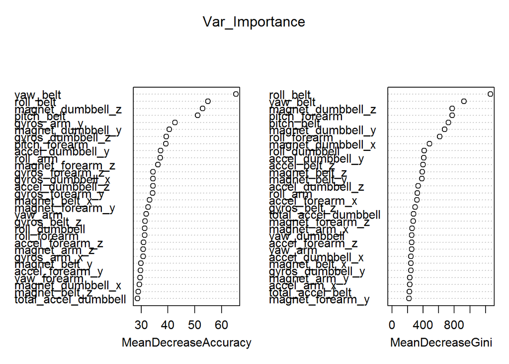

```r
#var_Importance<-randomForest(classe~., data =training, importance =TRUE, do.trace = 100)
varImpPlot(Var_Importance)
```

# Applying the prediction model to the testing set for results

```r
predictions<-predict(modFit, newdata=training)
head(predictions,20)
```

[1] A A A A A A A A A A A A A A A A A A A A Levels: A B C D E

```r
predictions<-predict(modFit, newdata=trainingSet)
head(predictions,20)
```

[1] A A A A A A A A A A A A A A A A A A A A Levels: A B C D E

```r
prediction2<-predict(modFit, newdata=testing)
prediction2
```

[1] B A B A A E D B A A B C B A E E A B B B Levels: A B C D E

```r
prediction2<-predict(modFit, newdata=testingSet)
prediction2
```

[1] B A B A A E D B A A B C B A E E A B B B Levels: A B C D E

```r
#write the answers into the files for scoring
pml_write_files = function(x){
  n = length(x)
  for(i in 1:n){
    filename = paste0("problem_id_",i,".txt")
    write.table(x[i],file=filename,quote=FALSE,row.names=FALSE,col.names=FALSE)
  }
}
answers<-prediction2
pml_write_files(answers)
```

## Conclusions

1. Random forest does prove to be one of the most accurate and automated ML methods for prediction
2. Using data from all sensors on belt,forearm,arm and dumbbell, our model can achieve >99% accuracy with <0.5% OOB error rate. Despite the result is a bit hard to explain since many predictors (52) are used.
3. Garbge in, Garge out. Raw data is more important than algorithm, the more the merier. During the experiment, using the exactly same algorithm, I found when using less and less data for training set, the accuracy become worse and worse correspondently.
4. Data cleaning, preprocessing and quick data exploration will greatly ease the predictive analysis work afterwards. Also during data processing the time sequence relationship between data should be preserved as data is related to a consecutive set of personal movements in a series of observation windows
5. Feature selection calls for domain expert knowledge. Corrleation-based feature selection is worth further study after this project

## Acknowledgement

All data for this project come from this source: http://groupware.les.inf.puc-rio.br/har.  
Thanks the Quantified Self Movement group for their generosity in making those data accessible for public use and research study